# 红葡萄酒质量探索

## chlorides & quality(氯化物 和 品质的关系)

。chlorides和quality的关系也有点儿像上面的density和quality的关系，品质越高， 氯化物的范围就越小，而且一般也是品质越高，氯化物含量也越少的变化。

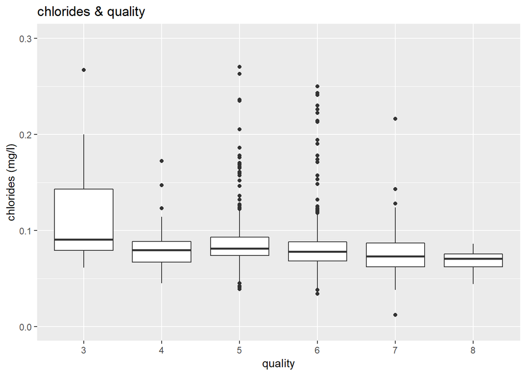

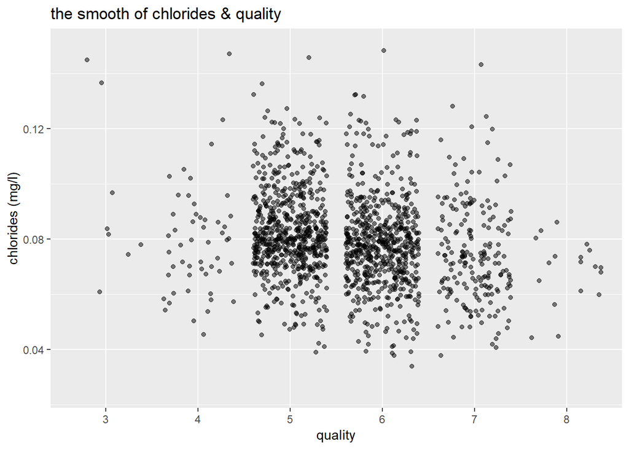

```
## wineQuantity$quality: 3
##    Min. 1st Qu.  Median    Mean 3rd Qu.    Max.
##  0.0610  0.0790  0.0905  0.1225  0.1430  0.2670
## --------------------------------------------------------
## wineQuantity$quality: 4
##    Min. 1st Qu.  Median    Mean 3rd Qu.    Max.
## 0.04500 0.06700 0.08000 0.09068 0.08900 0.61000
## --------------------------------------------------------
## wineQuantity$quality: 5
##    Min. 1st Qu.  Median    Mean 3rd Qu.    Max.
## 0.03900 0.07400 0.08100 0.09274 0.09400 0.61100
## --------------------------------------------------------
## wineQuantity$quality: 6
##    Min. 1st Qu.  Median    Mean 3rd Qu.    Max.
## 0.03400 0.06825 0.07800 0.08496 0.08800 0.41500
## --------------------------------------------------------
## wineQuantity$quality: 7
##    Min. 1st Qu.  Median    Mean 3rd Qu.    Max.
## 0.01200 0.06200 0.07300 0.07659 0.08700 0.35800
## --------------------------------------------------------
## wineQuantity$quality: 8
##    Min. 1st Qu.  Median    Mean 3rd Qu.    Max.
## 0.04400 0.06200 0.07050 0.06844 0.07550 0.08600
```

```
##
##   3   4   5   6   7   8
##  10  53 681 638 199  18
```

## chlorides & density

观察chlorides和density之间的关系，发现他们之间的相关性不是很强， 所以关系应该也不强。

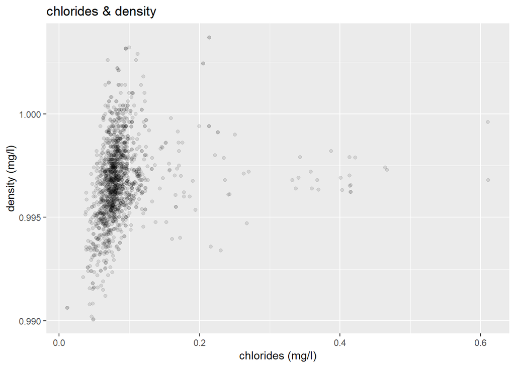

```
##
##  Pearson's product-moment correlation
##
## data:  wineQuantity$chlorides and wineQuantity$density
## t = 8.1842, df = 1597, p-value = 5.541e-16
## alternative hypothesis: true correlation is not equal to 0
## 95 percent confidence interval:
##  0.1531171 0.2472220
## sample estimates:
##       cor
## 0.2006323
```

## pH & quality

总体看起来pH是随着quality下降的一个关系，属于负相关的关系

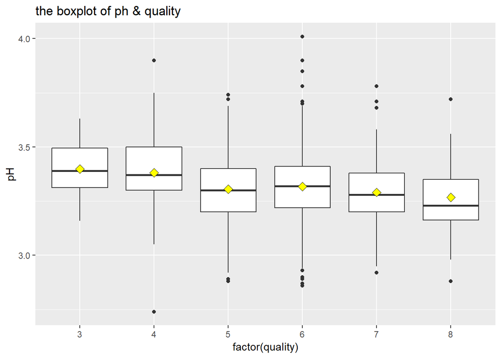

```
## wineQuantity$quality: 3
##    Min. 1st Qu.  Median    Mean 3rd Qu.    Max.
##   3.160   3.312   3.390   3.398   3.495   3.630
## --------------------------------------------------------
## wineQuantity$quality: 4
##    Min. 1st Qu.  Median    Mean 3rd Qu.    Max.
##   2.740   3.300   3.370   3.382   3.500   3.900
## --------------------------------------------------------
## wineQuantity$quality: 5
##    Min. 1st Qu.  Median    Mean 3rd Qu.    Max.
##   2.880   3.200   3.300   3.305   3.400   3.740
## --------------------------------------------------------
## wineQuantity$quality: 6
##    Min. 1st Qu.  Median    Mean 3rd Qu.    Max.
##   2.860   3.220   3.320   3.318   3.410   4.010
## --------------------------------------------------------
## wineQuantity$quality: 7
##    Min. 1st Qu.  Median    Mean 3rd Qu.    Max.
##   2.920   3.200   3.280   3.291   3.380   3.780
## --------------------------------------------------------
## wineQuantity$quality: 8
##    Min. 1st Qu.  Median    Mean 3rd Qu.    Max.
##   2.880   3.163   3.230   3.267   3.350   3.720
```

## 探索可能和 pH 相关的变量

3.free.sulfur.dioxide 游离二氧化硫 4.total.sulfur.dioxide 合计二氧化硫 5.sulphates 硫酸盐 9.citric.acid 柠檬酸 8.fixed.acidity 固定酸

按如下的几个图可以看出，citric.acid（柠檬酸）和fixed.acidity（固定酸）越多， pH越小，所以pH应该主要受这两个变量的影响，其他的变量变化较平，不明显的关系。

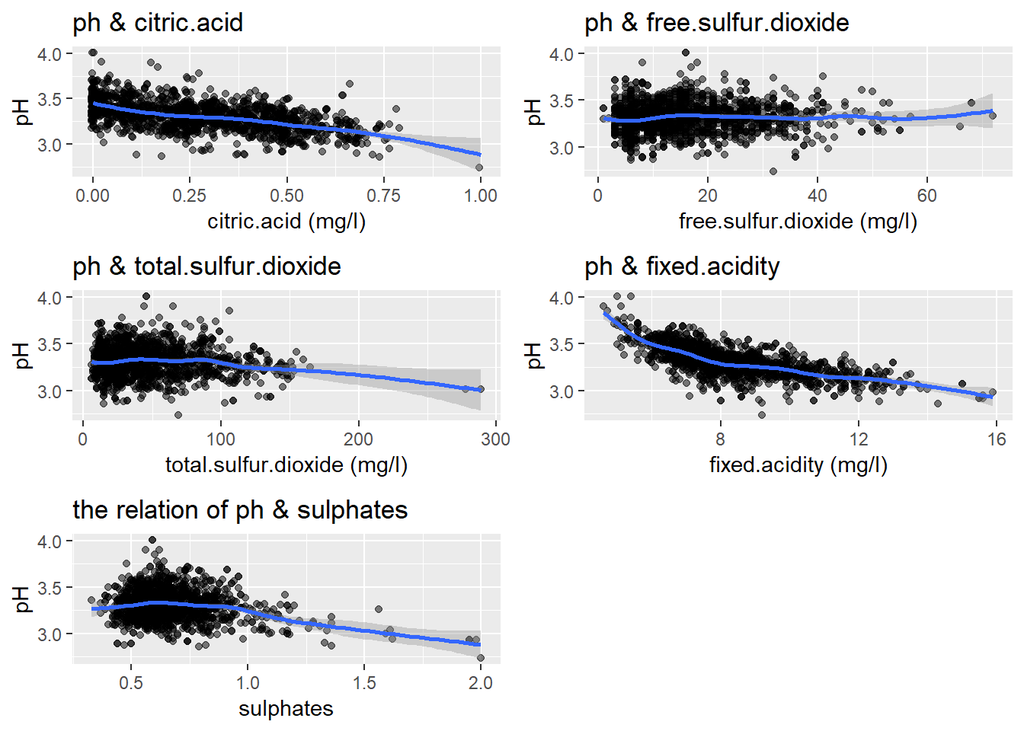

## sulphates & quality

sulphates 则是总体随着quality逐渐上升，硫酸盐含量越来越多。

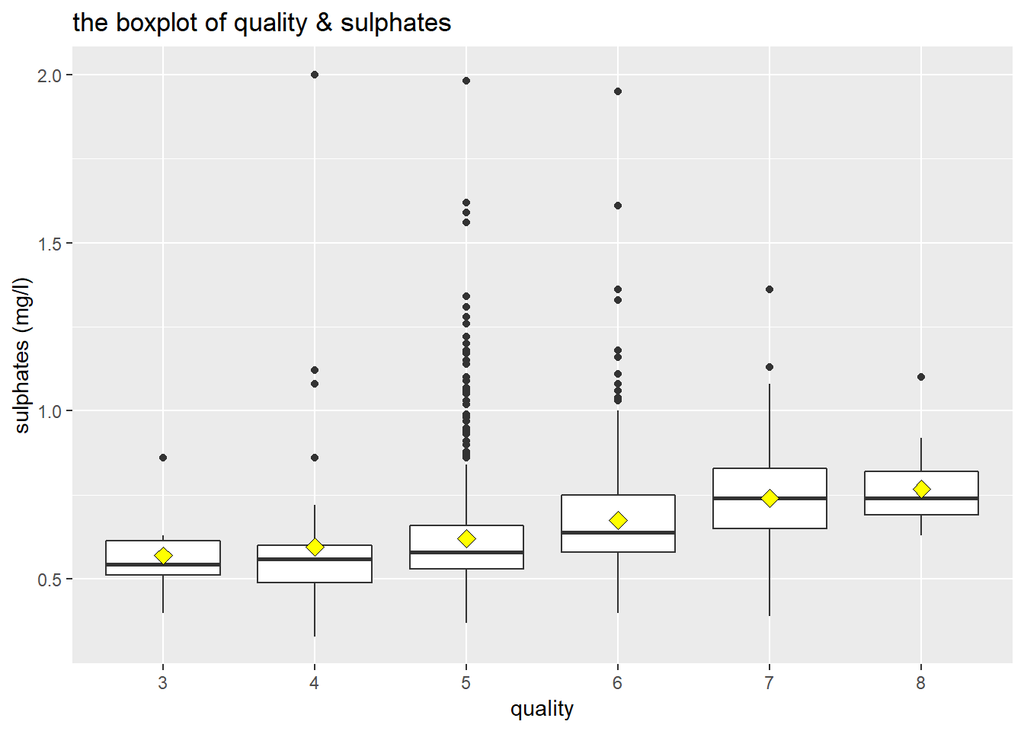

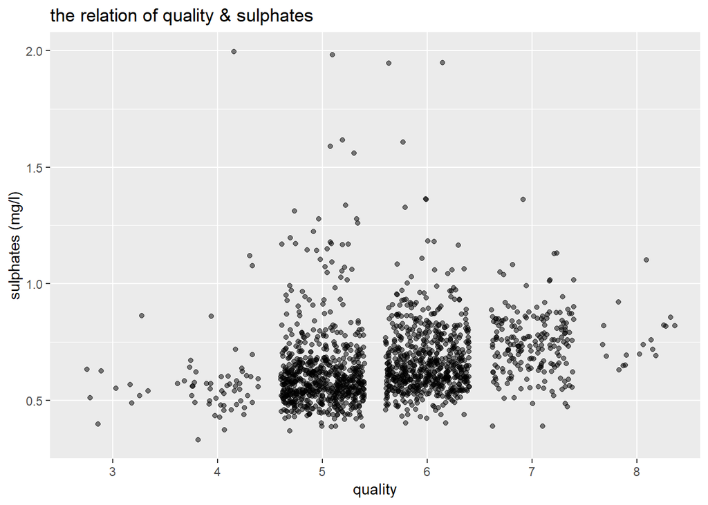

```
## wineQuantity$quality: 3
##    Min. 1st Qu.  Median    Mean 3rd Qu.    Max.
##  0.4000  0.5125  0.5450  0.5700  0.6150  0.8600
## --------------------------------------------------------
## wineQuantity$quality: 4
##    Min. 1st Qu.  Median    Mean 3rd Qu.    Max.
##  0.3300  0.4900  0.5600  0.5964  0.6000  2.0000
## --------------------------------------------------------
## wineQuantity$quality: 5
##    Min. 1st Qu.  Median    Mean 3rd Qu.    Max.
##   0.370   0.530   0.580   0.621   0.660   1.980
## --------------------------------------------------------
## wineQuantity$quality: 6
##    Min. 1st Qu.  Median    Mean 3rd Qu.    Max.
##  0.4000  0.5800  0.6400  0.6753  0.7500  1.9500
## --------------------------------------------------------
## wineQuantity$quality: 7
##    Min. 1st Qu.  Median    Mean 3rd Qu.    Max.
##  0.3900  0.6500  0.7400  0.7413  0.8300  1.3600
## --------------------------------------------------------
## wineQuantity$quality: 8
##    Min. 1st Qu.  Median    Mean 3rd Qu.    Max.
##  0.6300  0.6900  0.7400  0.7678  0.8200  1.1000
```

### 探索影响 sulphates 的变量

然后这儿开始研究一下什么变量最影响硫酸盐的含量，这儿考虑到几个酸性相关的，有 free.sulfur.dioxide 游离二氧化硫 total.sulfur.dioxide 合计二氧化硫 citric.acid 柠檬酸 fixed.acidity 固定酸

#### 观察去掉最大最小值后的sulphates和citric.acid 之间的关系

去掉前百分之10和后面百分之10 的数据的数据 看 citric.acid 和 sulphates 。整体看来无论是sulphates的均值，还是中位数，都是曲折上升的过程，看经过平滑处理 过的smooth曲线可以看出，整体citric.acid 越多，sulphates就越多。

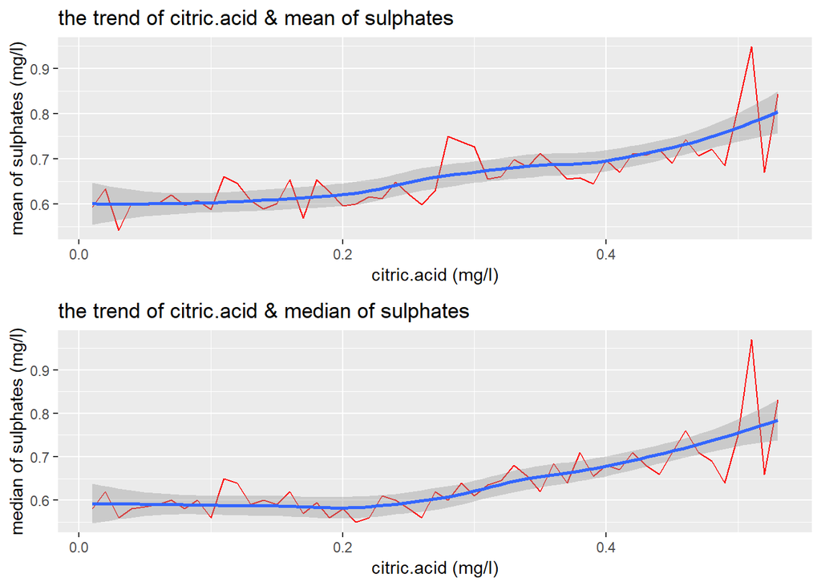

```
##
##  Pearson's product-moment correlation
##
## data:  subwinee$citric.acid and subwinee$sulphates
## t = 10.8, df = 1319, p-value < 2.2e-16
## alternative hypothesis: true correlation is not equal to 0
## 95 percent confidence interval:
##  0.2347002 0.3338298
## sample estimates:
##       cor
## 0.2850269
```

#### sulphates & fixed.acidity

同理，观察硫酸盐和其他酸的关系 fixed.acidity 和 sulphates 之间的关系变化也可以看出总体也是sulphates随着fixed.acidity的增加而增加的。

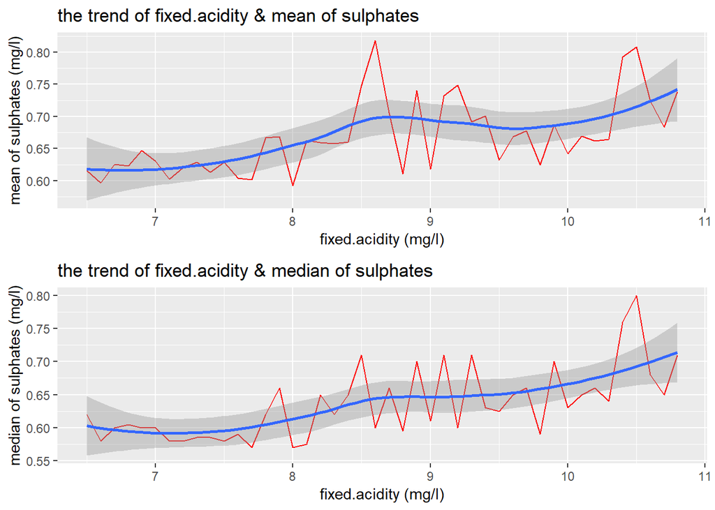

```
##
##  Pearson's product-moment correlation
##
## data:  subwinee2$fixed.acidity and subwinee2$sulphates
## t = 6.7196, df = 1305, p-value = 2.715e-11
## alternative hypothesis: true correlation is not equal to 0
## 95 percent confidence interval:
##  0.1299398 0.2347693
## sample estimates:
##       cor
## 0.1828743
```

#### sulphates & free.sulfur.dioxide

free.sulfur.dioxide 到22.5 这儿的时候sulphates有最大的值，然后就又下降了。 所以应该是有一定关系的，但是却不是直献的关系。

[output not shown]

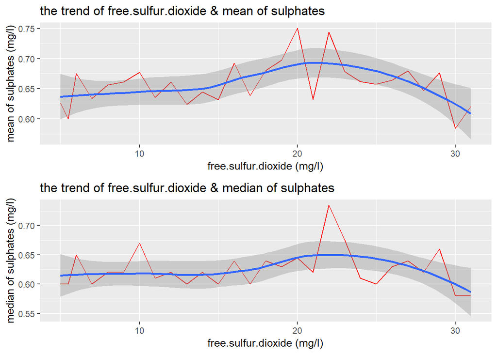

#### sulphates & total.sulfur.dioxide

而 sulphates & total.sulfur.dioxide 整体看齐来平滑后的曲线很平稳，所以存在波动， 但是可能对溶液中的sulphates影响比较小。

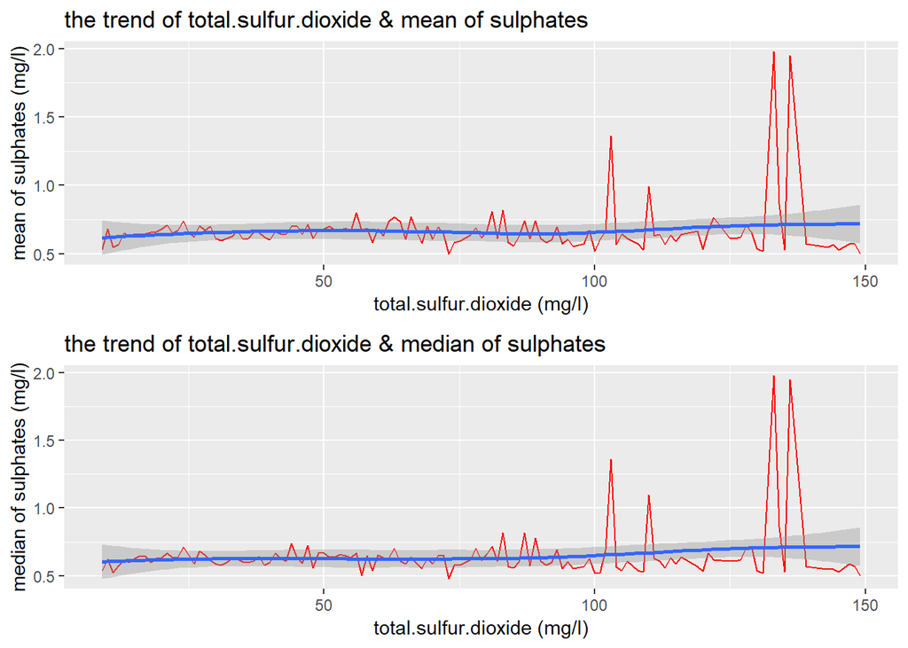

所以结果可能是sulphates和fixed.acidity、citric.acid有轻微的正相关性，但是和free.sulfur.dioxide 之间则是有一段上升长期，然后就下降。和total.sulfur.dioxide 影响不大。

## free.sulfur.dioxide & quality

这个变化中间有个起伏，他们之间的规律不明显

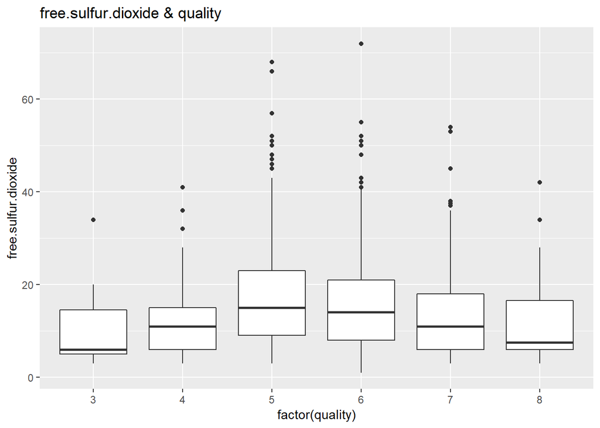

```
## wineQuantity$quality: 3
##    Min. 1st Qu.  Median    Mean 3rd Qu.    Max.
##     3.0     5.0     6.0    11.0    14.5    34.0
## --------------------------------------------------------
## wineQuantity$quality: 4
##    Min. 1st Qu.  Median    Mean 3rd Qu.    Max.
##    3.00    6.00   11.00   12.26   15.00   41.00
## --------------------------------------------------------
## wineQuantity$quality: 5
##    Min. 1st Qu.  Median    Mean 3rd Qu.    Max.
##    3.00    9.00   15.00   16.98   23.00   68.00
## --------------------------------------------------------
## wineQuantity$quality: 6
##    Min. 1st Qu.  Median    Mean 3rd Qu.    Max.
##    1.00    8.00   14.00   15.71   21.00   72.00
## --------------------------------------------------------
## wineQuantity$quality: 7
##    Min. 1st Qu.  Median    Mean 3rd Qu.    Max.
##    3.00    6.00   11.00   14.05   18.00   54.00
## --------------------------------------------------------
## wineQuantity$quality: 8
##    Min. 1st Qu.  Median    Mean 3rd Qu.    Max.
##    3.00    6.00    7.50   13.28   16.50   42.00
```

## total.sulfur.dioxide & quality

total.sulfur.dioxide 和 free.sulfur.dioxide 和quality之间可视化结果比较像。 看起来有起伏，但是好像看不出太明显的关系

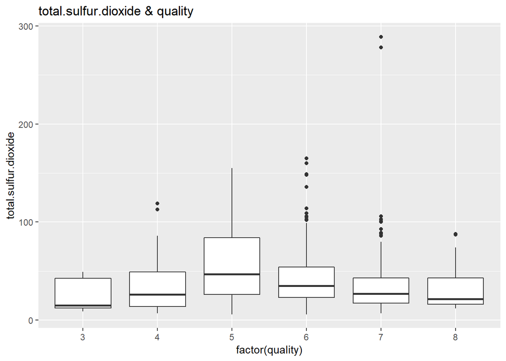

```
## wineQuantity$quality: 3
##    Min. 1st Qu.  Median    Mean 3rd Qu.    Max.
##     9.0    12.5    15.0    24.9    42.5    49.0
## --------------------------------------------------------
## wineQuantity$quality: 4
##    Min. 1st Qu.  Median    Mean 3rd Qu.    Max.
##    7.00   14.00   26.00   36.25   49.00  119.00
## --------------------------------------------------------
## wineQuantity$quality: 5
##    Min. 1st Qu.  Median    Mean 3rd Qu.    Max.
##    6.00   26.00   47.00   56.51   84.00  155.00
## --------------------------------------------------------
## wineQuantity$quality: 6
##    Min. 1st Qu.  Median    Mean 3rd Qu.    Max.
##    6.00   23.00   35.00   40.87   54.00  165.00
## --------------------------------------------------------
## wineQuantity$quality: 7
##    Min. 1st Qu.  Median    Mean 3rd Qu.    Max.
##    7.00   17.50   27.00   35.02   43.00  289.00
## --------------------------------------------------------
## wineQuantity$quality: 8
##    Min. 1st Qu.  Median    Mean 3rd Qu.    Max.
##   12.00   16.00   21.50   33.44   43.00   88.00
```

## volatile.acidity & quality

volatile.acidity & quality 之间的关系就比较明显了。volatile.acidity挥发性酸 整体随着quality 的增加而减少。负相关性比较强

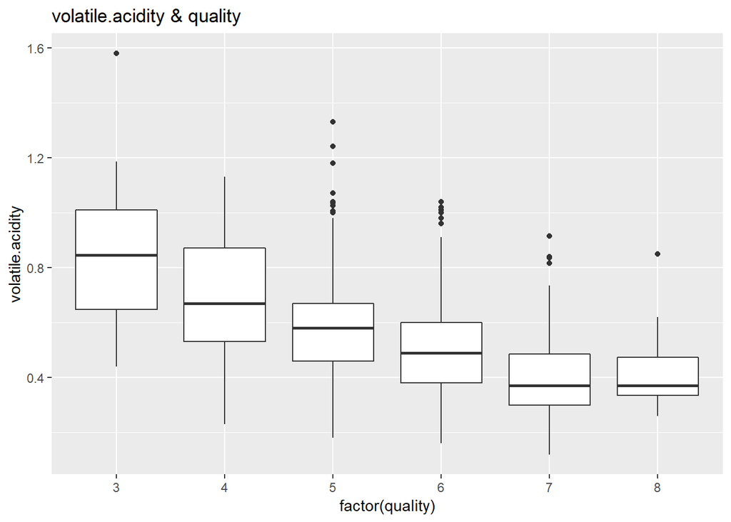

[output not shown]

## 探索各个变量之间的相关性强弱的关系

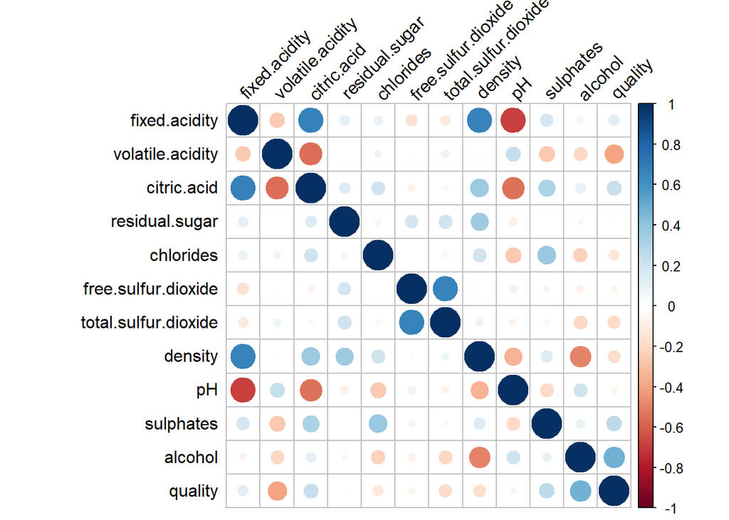

# 双变量绘图选择

双变量绘图的时候主要使用ggplot的箱线图，和散点图来进行两个变量的可视化操作。 还可以用折线图 # 双变量分析

### 探讨你在这部分探究中观察到的一些关系。这些感兴趣的特性与数据集内其他特性有什么区别？

比较感兴趣的是residual.sugar 和quality的关系。 但是发现残留糖对品质基本上没什么影响， 不过由这个变量衍生出来的红酒品种变量wine.class 可以看出 ， 大家可能比较喜欢喝不甜的红酒，也就是干型红酒，或者半干型， 因为数据集中的这两种酒占比最多。

### 你是否观察到主要特性与其他特性之间的有趣关系？

从开头的ggpair图中可以找到与quality相关性比较强的如下的几种关系。

quality 和 volatile.acidity -0.391比较强的负相关的关系。

quality 和 citric.acid（柠檬酸） 相关性= 0.228 有轻微的正相关关系

quality & sulphates corr = 0.251 中等程度相关

### 你发现最强的关系是什么？

alcohol 和 volatile.acidity 对quality的关系比较强。

### 你发现最强的关系是什么？

发现与quality最强的关系是：

alcohol,volatile.acidity,citric.acid,sulphates 与quality的关系比较强。

然后alcohol 与density 的关系比较强。

pH与citric.acid 和 fixed.acid的关系比较强

citric.acid 又与 fixed.acid 和 volatile.acidity 的关系比较强

density 和 fixed.acid 关系很强。

# 多变量分析

为了方便观察品质的情况，我们再次创建一个新的变量 qclass,  
把数据集中有的6个品质划分为3个品质，分别是low，median，good  
由下图以及拟合出的直线可以看出。

(1)citric.acid 越多，volatile.acidity 越少 的红酒的品质会越好

(2)alcohol 酒精含量越高，citric.acid 柠檬酸越多的红酒品质会越好。

(3)alcohol 酒精含量越多，volatile.acidity 挥发酸越少的红酒品质会越好。

(4)alcohol 酒精含量越高，sulphates 硫酸盐越多的红酒品质会越好。

所以我们可以有一个简单的结论，alcohol 酒精含量越高，citric.acid 柠檬酸越多，  
volatile.acidity 挥发酸越少，sulphates 硫酸盐越多的情况下的红酒品质会越好。

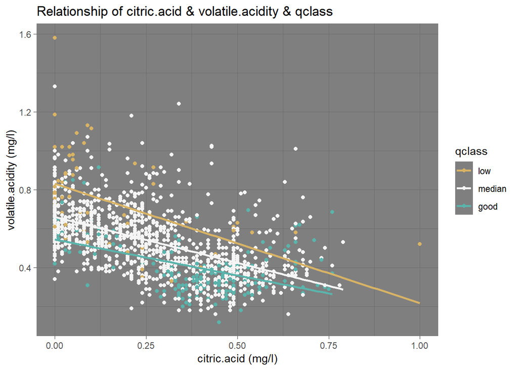

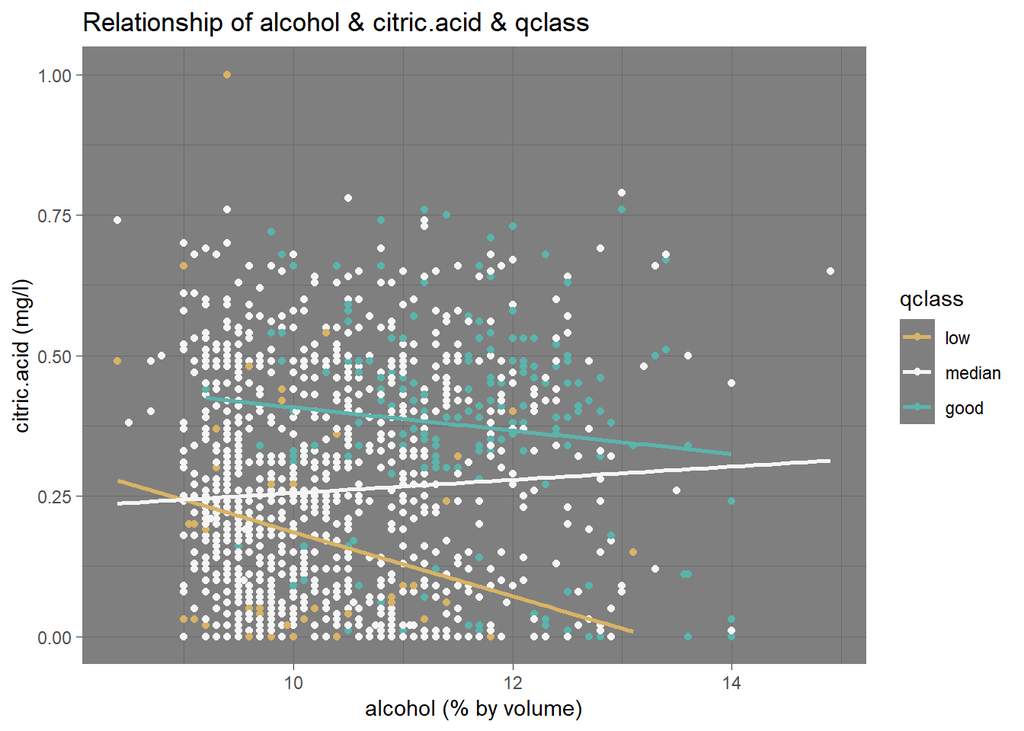

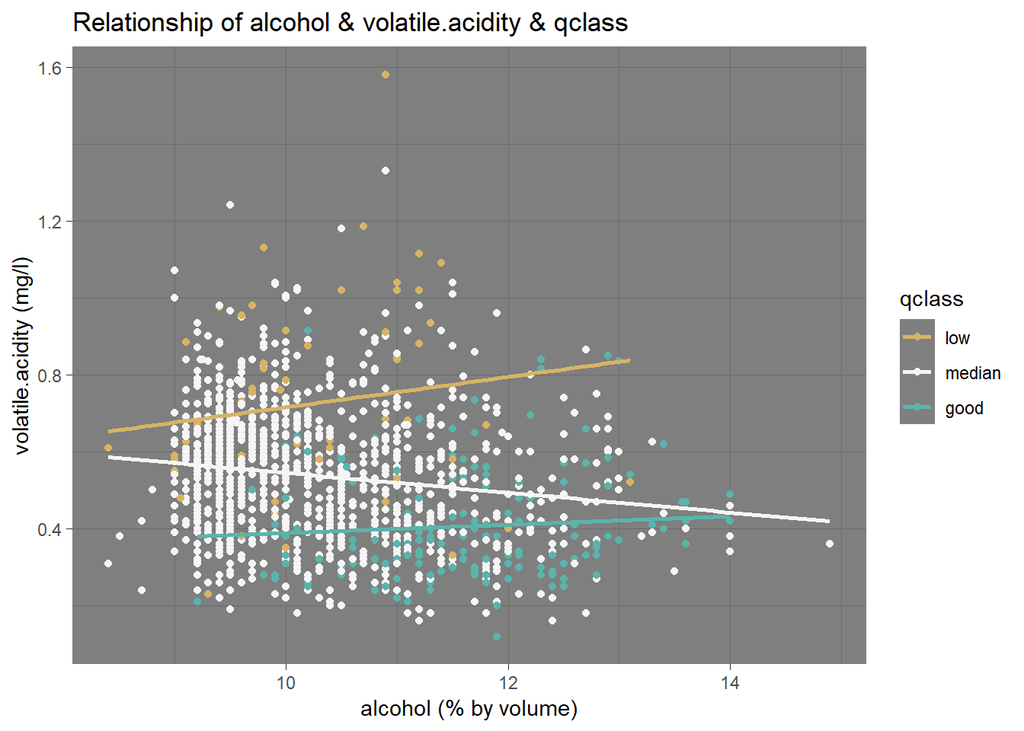

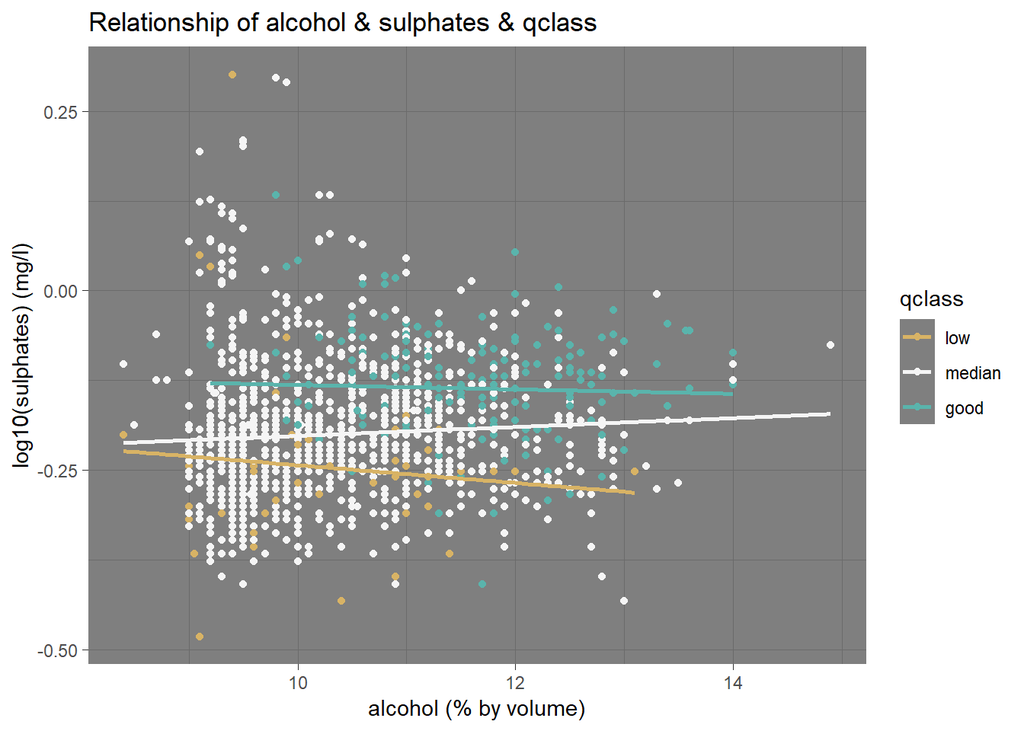

# 多变量绘图选择

多变量中我们主要使用了点图来进行多变量数据的数据可视化操作。

### 探讨你在这部分探究中观察到的一些关系。通过观察感兴趣的特性，是否存在相互促进的特性？

由之前的ggpair点图矩阵可以看到一下的变量会有比较强的相关性。 其中有很多变量具有相互促进的特征，比如最终我们发现 alcohol 酒精含量越高， citric.acid 柠檬酸越多，sulphates 硫酸盐越多会共同促进 红酒的品质更好等。

citric.acid & fixed.acidity 0.672 强相关  
citric.acid & volatile.acidity -0.552 中等程度相关  
total.sulfur.dioxide & free.sulfur.dioxide 0.668 强相关  
density & fixed.acidity 0.668 强相关  
pH & fixed.acidity -0.683 负相关 强相关  
pH & citric.acid -0.542 中等程度相关  
alcohol & density -0.496 中等程度相关  
quality & alcohol 0.476 中等程度相关

### 这些特性之间是否存在有趣或惊人的联系呢？

1.比如sulphates 硫酸盐，就和 citric.acidity，fixed.acidity 等酸有关。

2.然后一开始感兴趣的含糖量在都是可以出品(发酵好出品)的情况下，

发现人们一般比较喜欢干型，半干型的红酒，而半甜甚至是甜型的红酒的数据都比较少，

所以市面上的红酒品尝起来应该不怎么甜。

3.然后发现二氧化硫虽然算是大气污染物，

不过在剂量不对人造成伤害的情况下，

还可以做红酒的保鲜剂。等

# 定稿图与总结

### 绘图一

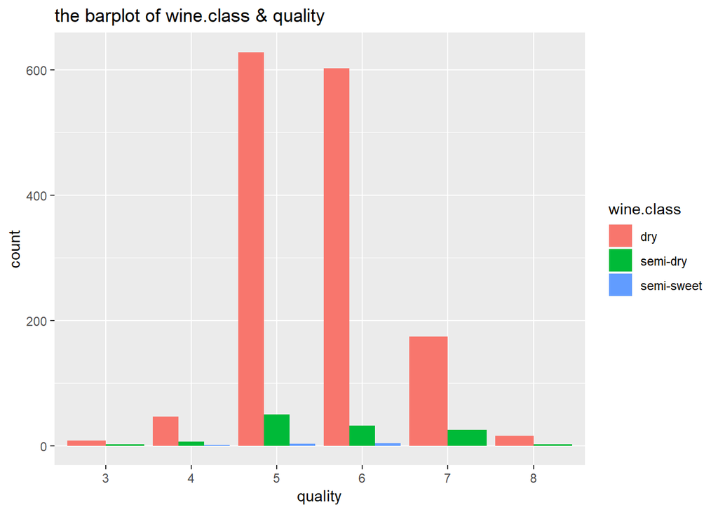

### 描述一

红酒的类型（按含糖划分的类型）和红酒的品质无关，但是大家喝得比较多的是干型、半干型的红酒。

### 绘图二

影响红酒质量的最主要的四个变量

[figure not shown]

### 描述二

上面的四个图可以得到如下的四个关系:  
(1)citric.acid 越多，volatile.acidity 越少 的红酒的品质会越好  
(2)alcohol 酒精含量越高，citric.acid 柠檬酸越多的红酒品质会越好。  
(3)alcohol 酒精含量越多，volatile.acidity 挥发酸越少的红酒品质会越好。  
(4)alcohol 酒精含量越高，sulphates 硫酸盐越多的红酒品质会越好。

### 绘图三

```
## [1] -0.1749192
```

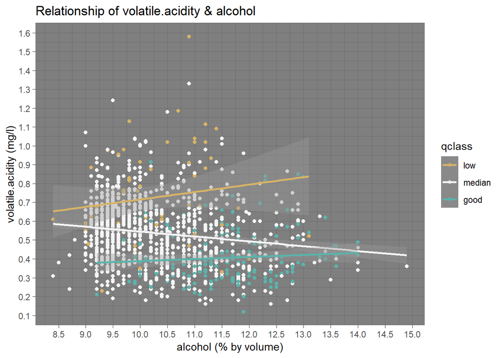

### 描述三

最后查看这两个变量alcohol和 volatile.acidity 谁对红酒品质影响比较大。 我们可以看到alcohol酒精含量从9.25 到 13.0之间 存在着三个等级的品质， 而看y轴 volatile.acidity 可以看到大概volatile.acidity为 0.65这儿是low和median品 质分级的分界点，然后volatile.acidity 为0.45是median和good品质的分界点， 可以看到比较明显的分界判定。所以个人推测， volatile.acidity挥发酸应该是对品质判定影响比较大。

结论总结，红酒的品质判定受很多的变量的影响， 其中里面影响比较大的成分为 alcohol 、volatile.acidity、 citric.acid、sulphate。 其中在这四个变量之中影响最明显的应该是volatile.acidity的含量。 得出的总的判定结论是，红酒中的alcohol, ,citric.acid,sulphates 越多， volatile.acidity越少，红酒的品质酒越高。 ——

# 反思

## 过程中遇到的难点

这次项目三探索性数据分析中遇到的难点是：视频很多，练习很多，需要勤奋的去刷视频。这次是项目三探索性数据分析感觉自己做了实在是有些久了，前后跨越一个月有了。个人感觉问题出在自己一开始没有对探索性数据分析的整体目的和流程的意义有有比较清晰的理解。然后就是可能自己对学过的知识也没有一个特别好的整理的方法和习惯，导致我做项目三的时候，视频课是刷完了，但是可能有些细节不记得，想回看的时候却找很久，不方便。然后我开始做的时候甚至感觉自己知道了流程，但是不知道每个流程的具体意义，可视化不知道选择哪些可视化图表来帮助自己达到自己的目的，这个当然也和我的基础不够扎实有关，什么时候用哪种可视化这个也需要总结一下才可以。这些都是需要针对性去客服的。

## 过程中成功的发现部分

然后这个探索的过程开始理解后会变得有意思很多，因为自己突然感觉自己可以从数据集中比较深入的理解和探索一样事务，是很有意思的。现在对红酒也理解很多了，挺有意思的。这次探索过程中发现了很多有意思的东西。  
比如 ：  
1.发现了红酒含糖不同可以分成 干型，半干型，半甜型，甜型的四种红酒类型  
2.发现了大部分红酒都是 属于干型的，然后红酒多是品尝起来有酸味的  
3.发现红酒中需要充SO2，用来让红酒更好的发酵，和防腐作用（查资料） 4.然后还发现 一般而言，红酒中的alcohol, ,citric.acid,sulphates 越多，volatile.acidity越少，红酒的品质酒越高。

## 未来如何进一步丰富分析内容和提高报告质量

因为暂时对线性模型的建立和线性模型不太了解，所以这次的分析报告里面并没有建立线性模型。后续改进的化，可以根据探索的结果建立信星模型，方便更好的预测红酒品质。